# Άσκηση 1 - Ανάλυση Ποσοστού Ανεργίας Ιταλίας

2026-06-14

# 1 Εισαγωγή

Ανάλυση μηνιαίου ποσοστού ανεργίας της Ιταλίας για την περίοδο **2022–2026**, με δεδομένα από την **Eurostat**. Στόχος είναι η προσαρμογή μοντέλου **ARIMA** μέσω μεθοδολογίας Box-Jenkins.

# 2 Φόρτωση Βιβλιοθηκών

```r
library(readxl)    # Για φόρτωση Excel αρχείων
library(forecast)  # Για ARIMA μοντέλα και προβλέψεις
library(tseries)   # Για στατιστικούς ελέγχους (ADF test)
```

# 3 Φόρτωση Δεδομένων

```r
# Διαβάζουμε το Excel αρχείο της Eurostat
# Η σειρά 12 αντιστοιχεί στην Ιταλία
# Οι στήλες από B και μετά περιέχουν τις μηνιαίες τιμές
all_data <- read_excel("italy_unemployment.xlsx", col_names = FALSE)

italy_row <- all_data[12, 2:ncol(all_data)]

# Μετατροπή σε αριθμητικό διάνυσμα και αφαίρεση κενών τιμών
italy_vector <- as.numeric(unlist(italy_row))
italy_vector <- italy_vector[!is.na(italy_vector)]

# Δημιουργία χρονοσειράς: μηνιαία από Ιανουάριο 2022
italy_ts <- ts(italy_vector, start = c(2022, 1), frequency = 12)

cat("Πλήθος παρατηρήσεων:", length(italy_ts), "\n")
```

```
## Πλήθος παρατηρήσεων: 51
```

```r
print(italy_ts)
```

```
##      Jan Feb Mar Apr May Jun Jul Aug Sep Oct Nov Dec
## 2022 9.1 8.7 8.5 8.2 7.8 7.8 7.4 7.7 7.9 8.1 7.8 7.9
## 2023 8.4 8.3 8.2 8.0 7.5 7.0 7.5 6.9 7.5 8.1 7.6 7.0
## 2024 7.6 8.1 7.4 6.8 6.5 6.7 5.9 5.3 5.6 5.8 5.8 6.7
## 2025 7.1 6.6 6.7 6.1 6.9 6.6 5.8 5.2 5.9 5.5 5.4 5.7
## 2026 4.9 5.4 5.5
```

# 4 Χρονοδιάγραμμα Αρχικής Σειράς (Ερώτημα α)

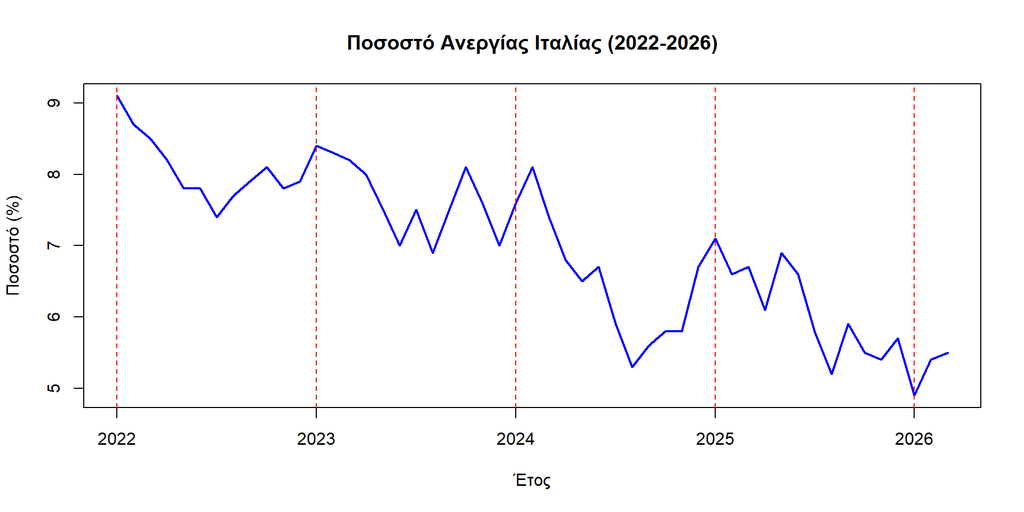

```r
par(bg = "white")
plot(italy_ts,
     main = "Ποσοστό Ανεργίας Ιταλίας (2022-2026)",
     ylab = "Ποσοστό (%)", xlab = "Έτος",
     col = "blue", lwd = 2)
abline(v = 2022:2026, col = "red", lty = "dashed")
```

**Παρατηρήσεις:**

- Ξεκάθαρη καθοδική τάση από περίπου 9.1% (Ιαν. 2022) έως 5.5% (αρχές 2026)
- Αντικατοπτρίζει την ανάκαμψη της ιταλικής αγοράς εργασίας μετά την πανδημία
- Υπάρχουν μικρές εποχικές διακυμάνσεις που επικαλύπτονται από την τάση
- Η σειρά κρίνεται **μη στάσιμη** λόγω ισχυρής τάσης

# 5 ACF & PACF Αρχικής Σειράς (Ερώτημα β)

## 5.1 ACF Αρχικής Σειράς

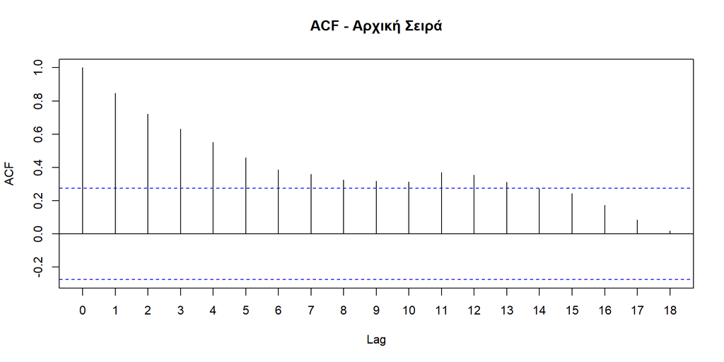

```r
acf(italy_ts, lag.max = 18, xaxt = "n",
    main = "ACF - Αρχική Σειρά")
axis(1, at = 0:18/12, labels = 0:18)
```

**Παρατήρηση:** Αργή, γραμμική φθίνουσα πορεία — όλοι οι συντελεστές lags 1-13 εκτός ορίων. Χαρακτηριστικό σήμα μη στάσιμης σειράς με τάση. Η υψηλή συσχέτιση για πολλά lags σημαίνει ότι η ανεργία κάθε μήνα εξαρτάται από τις τιμές πολλών προηγούμενων μηνών — χαρακτηριστικό σειράς που δεν επιστρέφει σε σταθερό μέσο.

## 5.2 PACF Αρχικής Σειράς

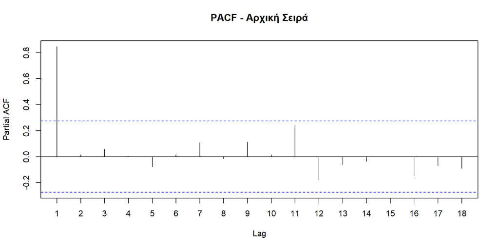

```r
pacf(italy_ts, lag.max = 18, xaxt = "n",
     main = "PACF - Αρχική Σειρά")
axis(1, at = 1:18/12, labels = 1:18)
```

**Παρατήρηση:** Σημαντική κορυφή αποκλειστικά στο lag 1 (~0.85), όλοι οι υπόλοιποι εντός ορίων. Η ανεργία αυτού του μήνα εξαρτάται άμεσα μόνο από τον προηγούμενο μήνα. Η μεγάλη συσχέτιση του ACF για πολλά lags οφείλεται στη διαδοχική μεταβίβαση αυτής της εξάρτησης από μήνα σε μήνα.

**Συμπέρασμα:** Η αρχική σειρά δεν είναι στάσιμη. Δεν εφαρμόζεται απευθείας ARMA μοντέλο. Απαιτείται διαφοροποίηση.

# 6 Πρώτες Διαφορές & Έλεγχος Στασιμότητας (Ερώτημα γ)

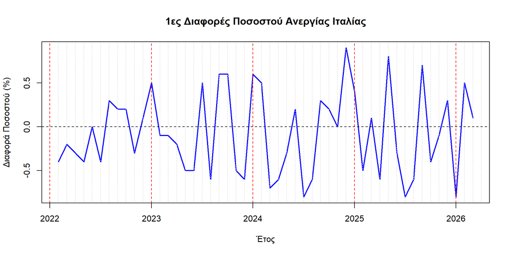

```r
# Υπολογισμός πρώτων διαφορών
# Κάθε τιμή = μεταβολή ανεργίας σε σχέση με τον προηγούμενο μήνα
diff_italy <- diff(italy_ts)

par(bg = "white")
plot(diff_italy,
     main = "1ες Διαφορές Ποσοστού Ανεργίας Ιταλίας",
     ylab = "Διαφορά Ποσοστού (%)", xlab = "Έτος",
     col = "blue", lwd = 2,
     xaxt = "n")
axis(1, at = 2022:2027, labels = 2022:2027)
abline(v = seq(2022, 2027, by = 1/12), col = "lightgray", lty = "dotted")
abline(v = 2022:2027, col = "red", lty = "dashed")
abline(h = 0, col = "black", lty = 2)
box()
```

**Παρατήρηση:** Οι τιμές κυμαίνονται τυχαία γύρω από το μηδέν χωρίς μακροχρόνια κατεύθυνση-πρώτη ένδειξη στασιμότητας.

## 6.1 ACF Πρώτων Διαφορών

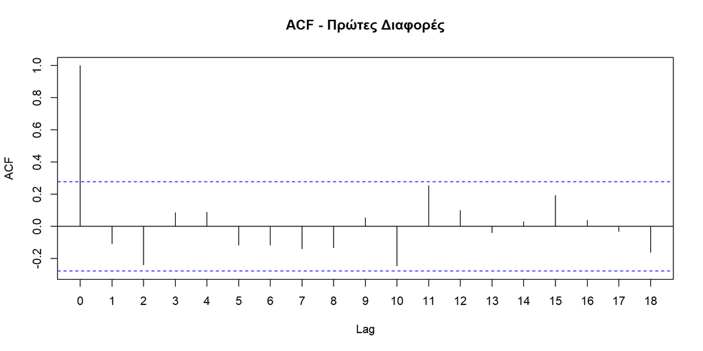

```r
acf(diff_italy, lag.max = 18, xaxt = "n",
    main = "ACF - Πρώτες Διαφορές")
axis(1, at = 0:18/12, labels = 0:18)
```

**Παρατήρηση:** Σχεδόν κανένα lag εκτός ορίων. Οι οριακά σημαντικές ράβδοι στα lags 2 10, 11 αποδίδονται σε τυχαία διακύμανση. Δεν υπάρχει συστηματικό μοτίβο — η διαφοροποιημένη σειρά προσεγγίζει λευκό θόρυβο.

## 6.2 PACF Πρώτων Διαφορών

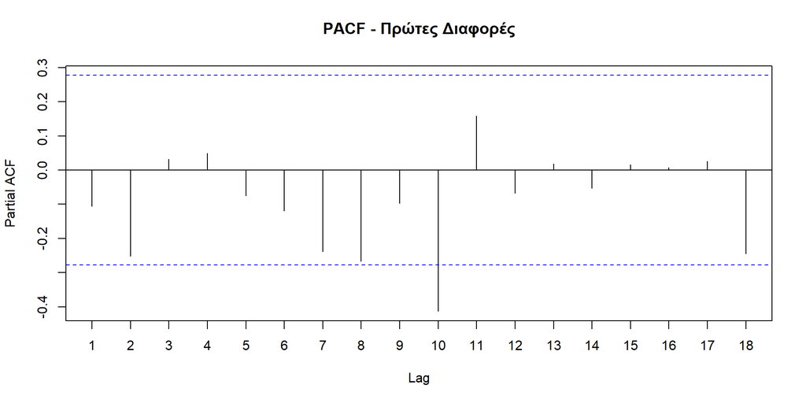

```r
pacf(diff_italy, lag.max = 18, xaxt = "n",
     main = "PACF - Πρώτες Διαφορές")
axis(1, at = 1:18/12, labels = 1:18)
```

**Παρατήρηση:** Μόνο το lag 10 βγαίνει εκτός ορίων (αρνητικά). Δεδομένου ότι δεν συνοδεύεται από αντίστοιχη σημαντική ράβδο στο ACF και δεν εντάσσεται σε συστηματικό μοτίβο, αποδίδεται σε τυχαία διακύμανση.

## 6.3 Augmented Dickey-Fuller Test

```r
# H0: Η σειρά ΔΕΝ είναι στάσιμη (υπάρχει μοναδιαία ρίζα)
# p-value < 0.05 → απόρριψη H0 → στάσιμη σειρά
adf.test(diff_italy)
```

```
##
##  Augmented Dickey-Fuller Test
##
## data:  diff_italy
## Dickey-Fuller = -3.5506, Lag order = 3, p-value = 0.04614
## alternative hypothesis: stationary
```

**Αποτέλεσμα:** p-value = 0.046 < 0.05 — απόρριψη μηδενικής υπόθεσης. Η σειρά πρώτων διαφορών είναι στάσιμη. Καθορίζεται **d = 1**. Δεν απαιτούνται δεύτερες διαφορές.

# 7 Προσαρμογή ARIMA Μοντέλου (Ερώτημα δ)

Βάσει ανάλυσης ACF/PACF των πρώτων διαφορών:

[output not shown]

Το μοντέλο **ARIMA(0,1,0)** αντιστοιχεί σε **random walk**: yt = yt-1 + εt

```r
model_010 <- arima(italy_ts, order = c(0, 1, 0))
cat("=== ARIMA(0,1,0) ===\n")
```

```
## === ARIMA(0,1,0) ===
```

```r
print(model_010)
```

```
##
## Call:
## arima(x = italy_ts, order = c(0, 1, 0))
##
##
## sigma^2 estimated as 0.2264:  log likelihood = -33.81,  aic = 69.62
```

```r
# Σύγκριση με auto.arima
auto_model <- auto.arima(italy_ts)
cat("\n=== auto.arima ===\n")
```

```
##
## === auto.arima ===
```

```r
print(auto_model)
```

```
## Series: italy_ts
## ARIMA(0,1,0)
##
## sigma^2 = 0.2264:  log likelihood = -33.81
## AIC=69.62   AICc=69.7   BIC=71.53
```

# 8 Σύγκριση Διευρυμένων Μοντέλων (Ερώτημα ζ - ΙΙ)

```r
# Δοκιμή μοντέλων ανώτερης τάξης για επιβεβαίωση επιλογής
model_110 <- arima(italy_ts, order = c(1, 1, 0))
model_011 <- arima(italy_ts, order = c(0, 1, 1))
model_111 <- arima(italy_ts, order = c(1, 1, 1))
model_210 <- arima(italy_ts, order = c(2, 1, 0))
model_012 <- arima(italy_ts, order = c(0, 1, 2))

cat("=== ARIMA(1,1,0) ===\n"); print(model_110)
```

```
## === ARIMA(1,1,0) ===
```

```
##
## Call:
## arima(x = italy_ts, order = c(1, 1, 0))
##
## Coefficients:
##           ar1
##       -0.0809
## s.e.   0.1406
##
## sigma^2 estimated as 0.2249:  log likelihood = -33.65,  aic = 71.29
```

```r
cat("\n=== ARIMA(0,1,1) ===\n"); print(model_011)
```

```
##
## === ARIMA(0,1,1) ===
```

```
##
## Call:
## arima(x = italy_ts, order = c(0, 1, 1))
##
## Coefficients:
##           ma1
##       -0.1320
## s.e.   0.1717
##
## sigma^2 estimated as 0.2238:  log likelihood = -33.53,  aic = 71.07
```

```r
cat("\n=== ARIMA(2,1,0) ===\n"); print(model_210)
```

```
##
## === ARIMA(2,1,0) ===
```

```
##
## Call:
## arima(x = italy_ts, order = c(2, 1, 0))
##
## Coefficients:
##           ar1      ar2
##       -0.1018  -0.2191
## s.e.   0.1382   0.1378
##
## sigma^2 estimated as 0.2137:  log likelihood = -32.42,  aic = 70.84
```

```r
cat("\n=== ARIMA(0,1,2) ===\n"); print(model_012)
```

```
##
## === ARIMA(0,1,2) ===
```

```
##
## Call:
## arima(x = italy_ts, order = c(0, 1, 2))
##
## Coefficients:
##           ma1      ma2
##       -0.0779  -0.1948
## s.e.   0.1417   0.1472
##
## sigma^2 estimated as 0.2157:  log likelihood = -32.65,  aic = 71.3
```

```r
cat("\n=== ARIMA(1,1,1) ===\n"); print(model_111)
```

```
##
## === ARIMA(1,1,1) ===
```

```
##
## Call:
## arima(x = italy_ts, order = c(1, 1, 1))
##
## Coefficients:
##          ar1      ma1
##       0.6539  -0.7963
## s.e.  0.2437   0.1864
##
## sigma^2 estimated as 0.2188:  log likelihood = -33,  aic = 72
```

```r
cat("\n=== Σύγκριση AIC ===\n")
```

```
##
## === Σύγκριση AIC ===
```

```r
cat("ARIMA(0,1,0) AIC:", AIC(model_010), "\n")
```

```
## ARIMA(0,1,0) AIC: 69.62126
```

```r
cat("ARIMA(1,1,0) AIC:", AIC(model_110), "\n")
```

```
## ARIMA(1,1,0) AIC: 71.29153
```

```r
cat("ARIMA(0,1,1) AIC:", AIC(model_011), "\n")
```

```
## ARIMA(0,1,1) AIC: 71.06947
```

```r
cat("ARIMA(1,1,1) AIC:", AIC(model_111), "\n")
```

```
## ARIMA(1,1,1) AIC: 72.0008
```

```r
cat("ARIMA(2,1,0) AIC:", AIC(model_210), "\n")
```

```
## ARIMA(2,1,0) AIC: 70.83637
```

```r
cat("ARIMA(0,1,2) AIC:", AIC(model_012), "\n")
```

```
## ARIMA(0,1,2) AIC: 71.29606
```

# 9 Έλεγχος Καταλοίπων (Ερώτημα ζ - Ι)

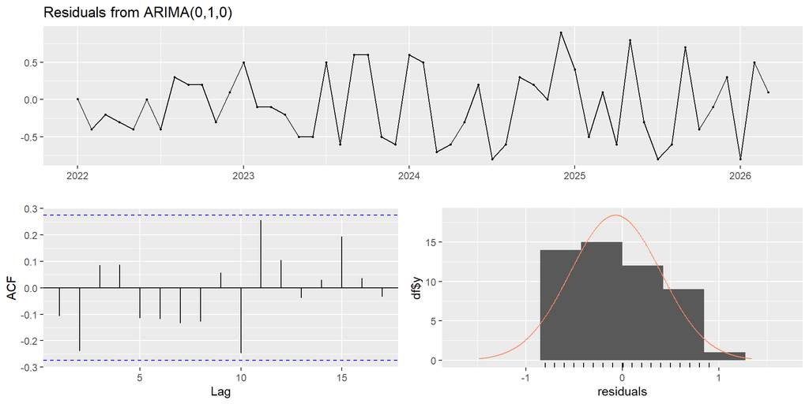

```
##
##  Ljung-Box test
##
## data:  Residuals from ARIMA(0,1,0)
## Q* = 12.599, df = 10, p-value = 0.247
##
## Model df: 0.   Total lags used: 10
```

```r
# Τα κατάλοιπα πρέπει να είναι λευκός θόρυβος
# checkresiduals: χρονοδιάγραμμα + ACF + ιστόγραμμα + Ljung-Box test
checkresiduals(model_010)
```

```r
# Δεύτερος έλεγχος Ljung-Box με 20 υστερήσεις (lags)
Box.test(residuals(model_010), lag = 20, type = "Ljung-Box")
```

```
##
##  Box-Ljung test
##
## data:  residuals(model_010)
## X-squared = 27.566, df = 20, p-value = 0.1201
```

**Αποτελέσματα:**

- Χρονοδιάγραμμα καταλοίπων: τυχαία κύμανση γύρω από μηδέν, χωρίς μοτίβο
- ACF καταλοίπων: σχεδόν όλες οι ράβδοι εντός ορίων
- Ιστόγραμμα: προσεγγίζει κανονική κατανομή
- Ljung-Box: Q* = 12.599, df = 10, p = 0.247 > 0.05 — τα κατάλοιπα είναι λευκός θόρυβος. Το μοντέλο κρίνεται κατάλληλο.

# 10 Πρόβλεψη 24 Μηνών (Ερώτημα η)

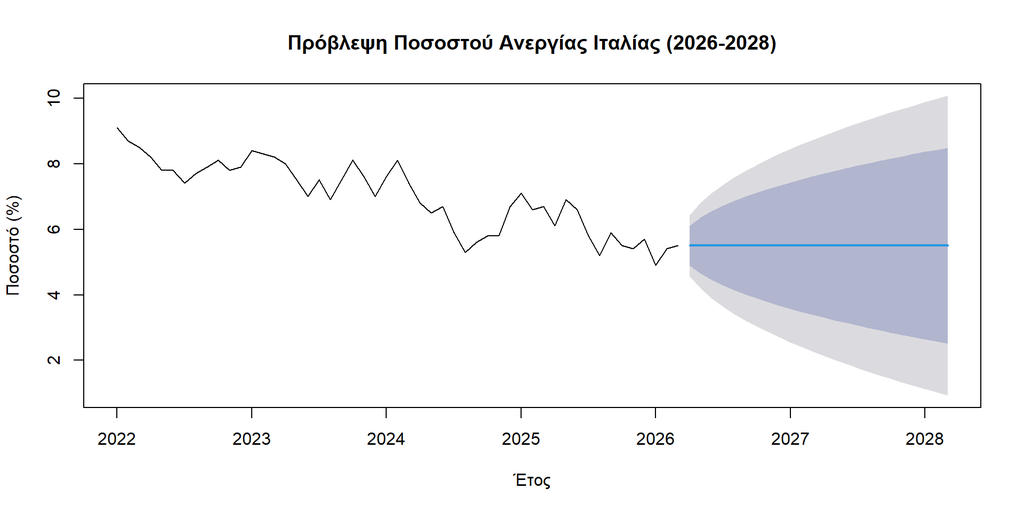

```r
# Πρόβλεψη για τα επόμενα 2 χρόνια (2026-2028)
forecast_italy <- forecast(model_010, h = 24)
plot(forecast_italy,
     main = "Πρόβλεψη Ποσοστού Ανεργίας Ιταλίας (2026-2028)",
     ylab = "Ποσοστό (%)", xlab = "Έτος")
```

# 11 Συμπεράσματα

- Η αρχική σειρά είναι **μη στάσιμη** λόγω καθοδικής τάσης
- Οι πρώτες διαφορές κατέστησαν τη σειρά στάσιμη (**d = 1**, ADF p = 0.046)
- Το βέλτιστο μοντέλο είναι **ARIMA(0,1,0)** — random walk — με AIC = 69.62
- Τα κατάλοιπα είναι **λευκός θόρυβος** (Ljung-Box p = 0.247)
- Η ανεργία μειώθηκε κατά ~40% σε 4 χρόνια — σημαντική ανάκαμψη αγοράς εργασίας μετά-COVID
- Το random walk υποδηλώνει ότι η αγορά εργασίας επηρεάζεται από απρόβλεπτους εξωγενείς παράγοντες